# Tugas Praktikum MPDW - ARIMA Suhu Rata-rata Harian Cilegon

Dzulfikar Najib

28 September 2026

# 1. Pembagian Data

Data yang digunakan adalah data suhu rata-rata harian Kota Cilegon (`Suhu_Rata2_C`). Data dimulai dari 1 Januari 2024. Data dibagi menjadi data *train* untuk membangun model dan data *test* untuk mengevaluasi hasil peramalan.

Pembagian data menggunakan **90% data sebagai train dan 10% sebagai test**. Pembagian ini digunakan agar data *train* cukup panjang untuk mengidentifikasi pola autokorelasi, sementara data *test* tetap tersedia untuk mengevaluasi kemampuan peramalan.

```r
df <- read.csv("cuaca_cilegon_10_tahun.csv")

df$Tanggal <- as.Date(df$Tanggal)

dat <- df[
  df$Tanggal >= as.Date("2024-01-01") &
    !is.na(df$Suhu_Rata2_C),
  c("Tanggal", "Suhu_Rata2_C")
]

dat <- dat[order(dat$Tanggal), ]

n <- nrow(dat)
n_train <- floor(0.90 * n)

train <- dat[1:n_train, ]
test  <- dat[(n_train + 1):n, ]

y_raw <- ts(train$Suhu_Rata2_C)

cat("Jumlah seluruh data :", n, "\n")
```

```
## Jumlah seluruh data : 997
```

```r
cat("Jumlah data train   :", nrow(train), "\n")
```

```
## Jumlah data train   : 897
```

```r
cat("Jumlah data test    :", nrow(test), "\n")
```

```
## Jumlah data test    : 100
```

```r
cat("Periode data        :", min(dat$Tanggal), "s.d.", max(dat$Tanggal), "\n")
```

```
## Periode data        : 19723 s.d. 20719
```

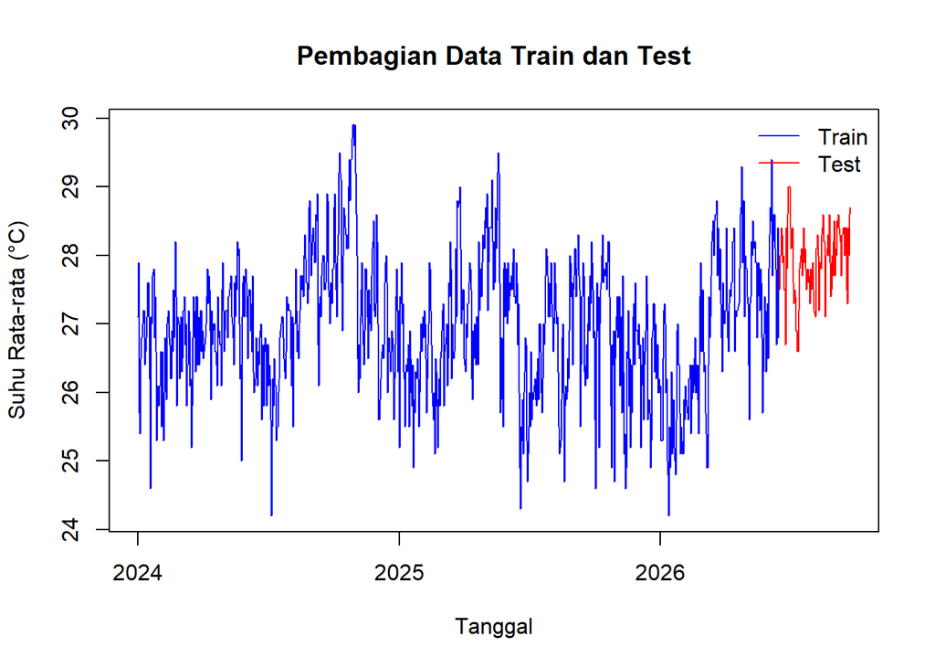

```r
plot(
  dat$Tanggal[1:n_train],
  train$Suhu_Rata2_C,
  type = "l",
  col = "blue",
  xlim = range(dat$Tanggal),
  ylim = range(dat$Suhu_Rata2_C),
  xlab = "Tanggal",
  ylab = "Suhu Rata-rata (°C)",
  main = "Pembagian Data Train dan Test"
)

lines(
  test$Tanggal,
  test$Suhu_Rata2_C,
  col = "red"
)

legend(
  "topright",
  legend = c("Train", "Test"),
  col = c("blue", "red"),
  lty = 1,
  bty = "n"
)
```

**Interpretasi:** Terdapat 997 amatan dari 2024-01-01 sampai 2026-09-23. Sebanyak 897 amatan digunakan sebagai data *train* dan 100 amatan digunakan sebagai data *test*.

# 2. Pemeriksaan Stasioneritas Data Train

## 2.1 Stasioneritas Ragam dengan Box-Cox

Stasioneritas ragam diperiksa menggunakan analisis Box-Cox. Jika selang kepercayaan 95% untuk parameter Box-Cox mengandung angka 1, data dianggap tidak memerlukan transformasi untuk menstabilkan ragam.

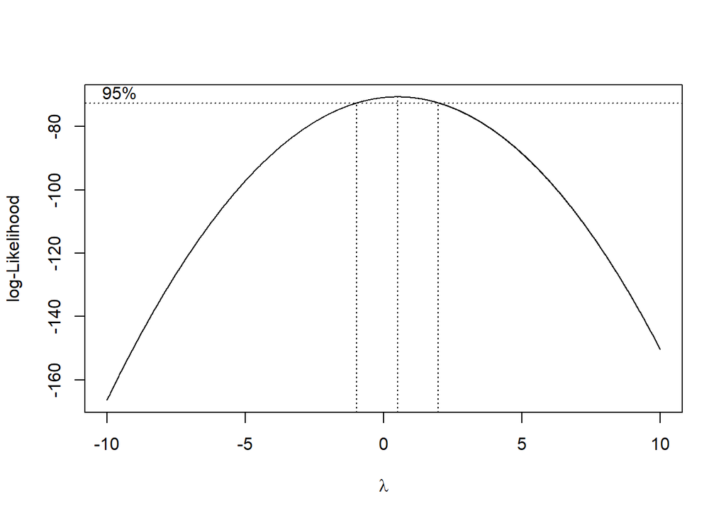

```r
bc <- boxcox(
  y_raw ~ 1,
  lambda = seq(-10, 10, by = 0.01),
  plotit = TRUE
)
```

```r
lambda_opt <- bc$x[which.max(bc$y)]

ci_bc <- range(
  bc$x[
    bc$y > max(bc$y) - qchisq(0.95, 1) / 2
  ]
)

lambda_opt
```

```
## [1] 0.51
```

```r
ci_bc
```

```
## [1] -0.97  1.98
```

```r
ragam_stasioner <- ci_bc[1] <= 1 && ci_bc[2] >= 1

if (ragam_stasioner) {
  lambda_used <- 1
  y_var <- y_raw
} else {
  lambda_used <- lambda_opt
  y_var <- BoxCox(y_raw, lambda = lambda_used)
}

cat("Lambda optimum :", round(lambda_opt, 3), "\n")
```

```
## Lambda optimum : 0.51
```

```r
cat("CI 95%         :", round(ci_bc[1], 3), "sampai", round(ci_bc[2], 3), "\n")
```

```
## CI 95%         : -0.97 sampai 1.98
```

```r
cat("Stasioner ragam :", ragam_stasioner, "\n")
```

```
## Stasioner ragam : TRUE
```

**Interpretasi:** Nilai lambda optimum adalah 0.51 dengan selang kepercayaan 95% sebesar [-0.97; 1.98]. Selang kepercayaan tersebut memuat angka 1, sehingga transformasi Box-Cox tidak diperlukan.

## 2.2 Stasioneritas Rataan dengan ACF dan ADF

Stasioneritas rataan diperiksa menggunakan ACF dan uji Augmented Dickey-Fuller (ADF). Pada uji ADF, hipotesis nol menyatakan bahwa data memiliki unit root (tidak stasioner).

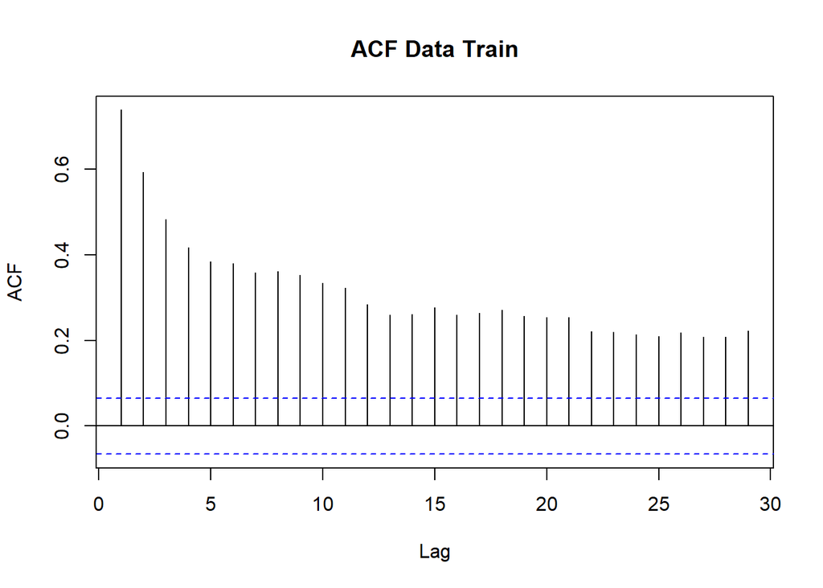

```r
acf(
  y_var,
  main = "ACF Data Train"
)
```

```r
adf <- adf.test(y_var)

adf
```

```
##
##  Augmented Dickey-Fuller Test
##
## data:  y_var
## Dickey-Fuller = -4.9899, Lag order = 9, p-value = 0.01
## alternative hypothesis: stationary
```

```r
mean_stasioner <- adf$p.value < 0.05

cat("ADF p-value :", format.pval(adf$p.value), "\n")
```

```
## ADF p-value : 0.01
```

```r
cat("Stasioner rataan :", mean_stasioner, "\n")
```

```
## Stasioner rataan : TRUE
```

**Interpretasi:** Uji ADF menghasilkan p-value 0.01. Nilai tersebut lebih kecil dari 0,05 sehingga H0 ditolak dan data dianggap stasioner dalam rataan.

# 3. Penanganan Ketidakstasioneran

Penanganan dilakukan sesuai hasil pemeriksaan pada tahap sebelumnya:

- Jika ragam belum stasioner, dilakukan transformasi Box-Cox.
- Jika rataan belum stasioner, dilakukan diferensiasi.
- Jika keduanya sudah stasioner, tidak dilakukan transformasi maupun diferensiasi.

```r
if (!ragam_stasioner) {
  y <- y_var
} else {
  y <- y_raw
}

if (!mean_stasioner) {
  d <- ndiffs(y, test = "adf")
  y_model <- diff(y, differences = d)
} else {
  d <- 0
  y_model <- y
}

cat("Orde diferensiasi d =", d, "\n")
```

```
## Orde diferensiasi d = 0
```

**Interpretasi:** Berdasarkan hasil pengujian, ragam sudah dianggap stasioner sehingga tidak dilakukan transformasi Box-Cox. Untuk rataan, data sudah stasioner sehingga tidak dilakukan diferensiasi.

# 4. Identifikasi Model Potensial

Setelah data dibuat stasioner, identifikasi model dilakukan menggunakan ACF, PACF, dan EACF.

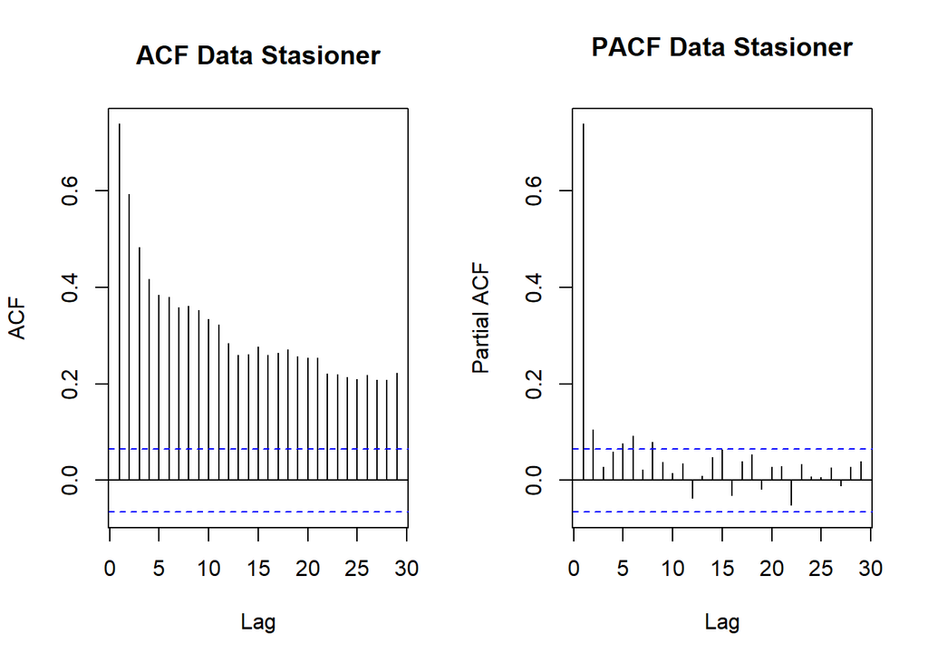

```r
par(mfrow = c(1, 2))

acf(
  y_model,
  main = "ACF Data Stasioner"
)

pacf(
  y_model,
  main = "PACF Data Stasioner"
)
```

```r
par(mfrow = c(1, 1))
```

```r
eacf(y_model)
```

```
## AR/MA
##   0 1 2 3 4 5 6 7 8 9 10 11 12 13
## 0 x x x x x x x x x x x  x  x  x
## 1 x o o o o o o o o o o  o  o  o
## 2 x o o o x o o o o o o  o  o  o
## 3 x x o o o o o o o o o  o  o  o
## 4 x x o o o o o o o o o  o  o  o
## 5 x o x x x o o o o o o  o  o  o
## 6 x x x o x o o o o o o  o  o  o
## 7 x x x x o x o o o o o  o  o  o
```

**Interpretasi:** ACF dan PACF digunakan untuk melihat pola ketergantungan antaramatan dan menentukan orde AR serta MA yang layak dipertimbangkan. EACF digunakan sebagai informasi tambahan dalam menentukan kandidat model ARMA/ARIMA.

> **Catatan:** Kandidat model pada bagian berikut dibuat berdasarkan pola ACF, PACF, dan EACF. Untuk data ini, kandidat yang diperiksa adalah model ARIMA(1,d,0), ARIMA(1,d,1), ARIMA(1,d,2), dan ARIMA(2,d,1).

```r
kand <- list(
  c(1, d, 0),
  c(1, d, 1),
  c(1, d, 2),
  c(2, d, 1)
)

model_names <- sapply(
  kand,
  function(o) paste0("ARIMA(", paste(o, collapse = ","), ")")
)

model_names
```

```
## [1] "ARIMA(1,0,0)" "ARIMA(1,0,1)" "ARIMA(1,0,2)" "ARIMA(2,0,1)"
```

# 5. Pendugaan Parameter dan Pemilihan Model

Setiap model kandidat diduga menggunakan fungsi `Arima()`. Model diperiksa berdasarkan signifikansi parameter dan nilai AIC.

```r
fits <- lapply(
  kand,
  function(o) {
    Arima(
      y,
      order = o,
      include.mean = (o[2] == 0)
    )
  }
)

for (i in seq_along(fits)) {
  cat("\n", model_names[i], "\n", sep = "")
  print(coeftest(fits[[i]]))
}
```

```
##
## ARIMA(1,0,0)
##
## z test of coefficients:
##
##            Estimate Std. Error z value  Pr(>|z|)
## ar1        0.738163   0.022437  32.899 < 2.2e-16 ***
## intercept 26.964046   0.083389 323.351 < 2.2e-16 ***
## ---
## Signif. codes:  0 '***' 0.001 '**' 0.01 '*' 0.05 '.' 0.1 ' ' 1
##
##
## ARIMA(1,0,1)
##
## z test of coefficients:
##
##            Estimate Std. Error  z value  Pr(>|z|)
## ar1        0.808207   0.027116  29.8055 < 2.2e-16 ***
## ma1       -0.157150   0.047483  -3.3096 0.0009342 ***
## intercept 26.964131   0.095241 283.1146 < 2.2e-16 ***
## ---
## Signif. codes:  0 '***' 0.001 '**' 0.01 '*' 0.05 '.' 0.1 ' ' 1
##
##
## ARIMA(1,0,2)
##
## z test of coefficients:
##
##            Estimate Std. Error  z value  Pr(>|z|)
## ar1        0.850015   0.037612  22.5996 < 2.2e-16 ***
## ma1       -0.205819   0.057141  -3.6019 0.0003159 ***
## ma2       -0.073582   0.054654  -1.3463 0.1781954
## intercept 26.964079   0.103886 259.5554 < 2.2e-16 ***
## ---
## Signif. codes:  0 '***' 0.001 '**' 0.01 '*' 0.05 '.' 0.1 ' ' 1
##
##
## ARIMA(2,0,1)
##
## z test of coefficients:
##
##            Estimate Std. Error z value  Pr(>|z|)
## ar1        1.540913   0.047669  32.325 < 2.2e-16 ***
## ar2       -0.552838   0.043573 -12.688 < 2.2e-16 ***
## ma1       -0.898639   0.031781 -28.276 < 2.2e-16 ***
## intercept 26.970633   0.177578 151.880 < 2.2e-16 ***
## ---
## Signif. codes:  0 '***' 0.001 '**' 0.01 '*' 0.05 '.' 0.1 ' ' 1
```

```r
sig_all <- sapply(
  fits,
  function(f) {
    pval <- coeftest(f)[, 4]
    all(pval < 0.05)
  }
)

tab_model <- data.frame(
  Model = model_names,
  AIC = sapply(fits, AIC),
  Semua_Parameter_Signifikan =
    ifelse(sig_all, "Ya", "Tidak")
)

tab_model
```

| Model | AIC | Semua_Parameter_Signifikan |
| --- | --- | --- |
| ARIMA(1,0,0) | 1795.996 | Ya |
| ARIMA(1,0,1) | 1787.045 | Ya |
| ARIMA(1,0,2) | 1787.225 | Tidak |
| ARIMA(2,0,1) | 1768.661 | Ya |

Model yang dipilih adalah model dengan parameter yang signifikan dan AIC terkecil di antara model yang memenuhi kriteria signifikansi.

```r
ok <- which(sig_all)

if (length(ok) == 0) {
  # Jika tidak ada model yang seluruh parameternya signifikan,
  # gunakan AIC terkecil dan beri catatan pada interpretasi.
  idx <- which.min(tab_model$AIC)
  alasan_pemilihan <- "Tidak ada kandidat dengan seluruh parameter signifikan; model dipilih berdasarkan AIC terkecil."
} else {
  idx <- ok[which.min(tab_model$AIC[ok])]
  alasan_pemilihan <- "Model dipilih dari kandidat dengan seluruh parameter signifikan dan AIC terkecil."
}

best_order <- kand[[idx]]
best <- fits[[idx]]
best_name <- model_names[idx]

cat("Model terpilih :", best_name, "\n")
```

```
## Model terpilih : ARIMA(2,0,1)
```

```r
cat("AIC            :", round(AIC(best), 3), "\n")
```

```
## AIC            : 1768.661
```

```r
cat("Alasan         :", alasan_pemilihan, "\n")
```

```
## Alasan         : Model dipilih dari kandidat dengan seluruh parameter signifikan dan AIC terkecil.
```

```r
coeftest(best)
```

```
##
## z test of coefficients:
##
##            Estimate Std. Error z value  Pr(>|z|)
## ar1        1.540913   0.047669  32.325 < 2.2e-16 ***
## ar2       -0.552838   0.043573 -12.688 < 2.2e-16 ***
## ma1       -0.898639   0.031781 -28.276 < 2.2e-16 ***
## intercept 26.970633   0.177578 151.880 < 2.2e-16 ***
## ---
## Signif. codes:  0 '***' 0.001 '**' 0.01 '*' 0.05 '.' 0.1 ' ' 1
```

**Interpretasi:** Berdasarkan kriteria signifikansi parameter dan AIC, model yang dipilih adalah **ARIMA(2,0,1)** dengan AIC sebesar 1768.661. Model dipilih dari kandidat dengan seluruh parameter signifikan dan AIC terkecil.

# 6. Analisis Sisaan

Setelah model diperoleh, dilakukan pemeriksaan terhadap sisaan untuk melihat apakah sisaan sudah menyerupai *white noise*. Pemeriksaan meliputi plot sisaan, ACF sisaan, QQ-plot, uji Ljung-Box, uji ARCH-LM, dan uji Shapiro-Wilk.

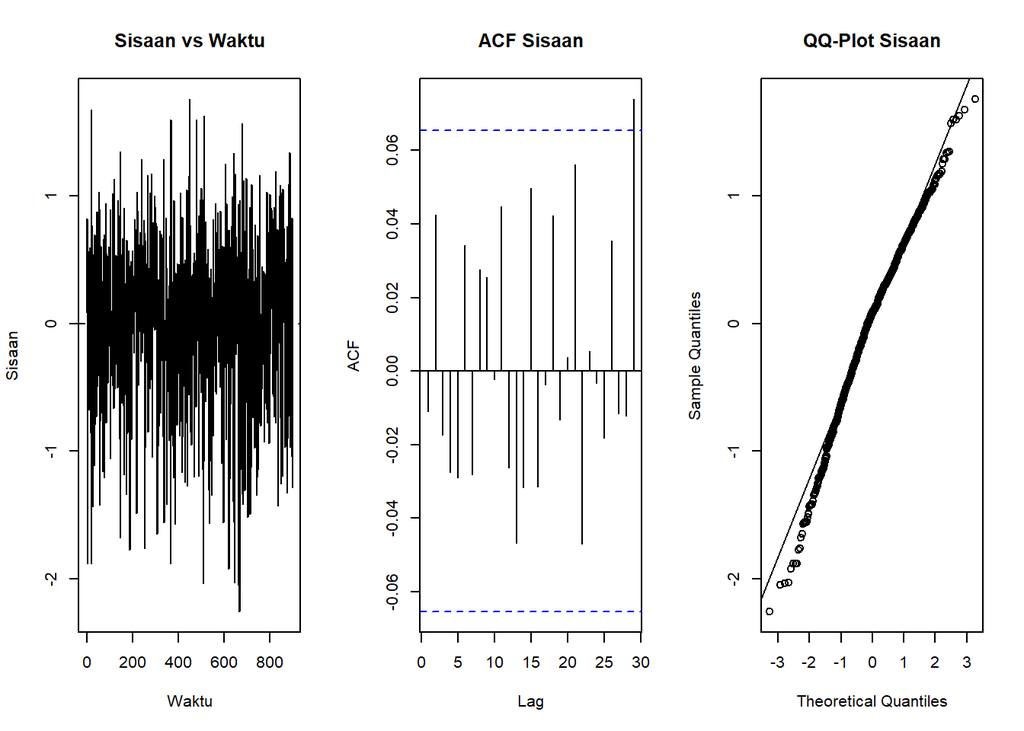

```r
res <- as.numeric(residuals(best))

par(mfrow = c(1, 3))

plot(
  res,
  type = "l",
  main = "Sisaan vs Waktu",
  xlab = "Waktu",
  ylab = "Sisaan"
)
abline(h = 0, lty = 2)

acf(
  res,
  main = "ACF Sisaan"
)

qqnorm(
  res,
  main = "QQ-Plot Sisaan"
)
qqline(res)
```

```r
par(mfrow = c(1, 1))
```

```r
lb <- Box.test(
  res,
  lag = 20,
  type = "Ljung-Box",
  fitdf = best_order[1] + best_order[3]
)

arch <- ArchTest(res)

sw <- shapiro.test(res)

lb
```

```
##
##  Box-Ljung test
##
## data:  res
## X-squared = 16.848, df = 17, p-value = 0.4647
```

```r
arch
```

```
##
##  ARCH LM-test; Null hypothesis: no ARCH effects
##
## data:  res
## Chi-squared = 27.632, df = 12, p-value = 0.006259
```

```r
sw
```

```
##
##  Shapiro-Wilk normality test
##
## data:  res
## W = 0.98511, p-value = 6.549e-08
```

**Interpretasi Ljung-Box:** p-value = 0.4647. Nilai p-value lebih besar dari 0,05 sehingga tidak terdapat bukti autokorelasi pada sisaan. Sisaan dapat dianggap tidak berkorelasi.

**Interpretasi ARCH-LM:** p-value = 0.006259. Nilai p-value lebih kecil dari 0,05 sehingga terdapat indikasi efek ARCH atau ragam sisaan tidak konstan.

**Interpretasi Shapiro-Wilk:** p-value = 6.549^{-8}. Nilai p-value lebih kecil dari 0,05 sehingga sisaan tidak mengikuti distribusi normal.

# 7. Uji Overfitting

Overfitting diperiksa dengan menaikkan orde AR sebanyak satu dan orde MA sebanyak satu dari model terpilih. Model hasil penambahan dibandingkan dengan model awal berdasarkan signifikansi parameter tambahan dan AIC.

```r
p <- best_order[1]
q <- best_order[3]

# Model dengan orde AR ditambah satu
f_ar <- tryCatch(
  Arima(
    y,
    order = c(p + 1, d, q),
    include.mean = (d == 0)
  ),
  error = function(e) NULL
)

# Model dengan orde MA ditambah satu
f_ma <- tryCatch(
  Arima(
    y,
    order = c(p, d, q + 1),
    include.mean = (d == 0)
  ),
  error = function(e) NULL
)

ov_list <- list(
  AR = f_ar,
  MA = f_ma
)

# Ambil p-value parameter tambahan dengan aman
get_extra_p <- function(fit, par_name) {
  if (is.null(fit)) return(NA_real_)

  ct <- tryCatch(coeftest(fit), error = function(e) NULL)

  if (is.null(ct) || !(par_name %in% rownames(ct))) {
    return(NA_real_)
  }

  ct[par_name, 4]
}

p_ar_extra <- get_extra_p(f_ar, paste0("ar", p + 1))
p_ma_extra <- get_extra_p(f_ma, paste0("ma", q + 1))

ov_tab <- data.frame(
  Model = c(
    paste0("ARIMA(", p + 1, ",", d, ",", q, ")"),
    paste0("ARIMA(", p, ",", d, ",", q + 1, ")")
  ),
  AIC = c(
    ifelse(is.null(f_ar), NA, AIC(f_ar)),
    ifelse(is.null(f_ma), NA, AIC(f_ma))
  ),
  Parameter_Tambahan = c(
    paste0("ar", p + 1),
    paste0("ma", q + 1)
  ),
  p_value = c(
    p_ar_extra,
    p_ma_extra
  )
)

ov_tab$Signifikan <- ifelse(
  is.na(ov_tab$p_value),
  "Model gagal diestimasi",
  ifelse(ov_tab$p_value < 0.05, "Ya", "Tidak")
)

ov_tab
```

| Model | AIC | Parameter_Tambahan | p_value | Signifikan |
| --- | --- | --- | --- | --- |
| ARIMA(3,0,1) | 1770.203 | ar3 | 5.005799e-01 | Tidak |
| ARIMA(2,0,2) | 1791.045 | ma2 | 2.197711e-16 | Ya |

```r
AIC(best)
```

```
## [1] 1768.661
```

```r
over_ok <- all(
  !is.na(ov_tab$p_value),
  ov_tab$p_value > 0.05,
  ov_tab$AIC >= AIC(best)
)

if (over_ok) {
  kesimpulan_over <- paste0(
    "Kedua parameter tambahan tidak signifikan dan AIC model yang lebih kompleks ",
    "tidak lebih kecil daripada model awal. Dengan demikian tidak terdapat ",
    "indikasi bahwa penambahan orde memberikan perbaikan model yang diperlukan, ",
    "sehingga ", best_name, " tetap digunakan."
  )
} else if (any(is.na(ov_tab$p_value))) {
  kesimpulan_over <- paste0(
    "Salah satu model overfitting tidak berhasil diestimasi sehingga pemeriksaan ",
    "overfitting tidak dapat dinyatakan lengkap berdasarkan kedua model tambahan."
  )
} else {
  kesimpulan_over <- paste0(
    "Terdapat model yang memiliki parameter tambahan signifikan atau AIC lebih ",
    "kecil daripada model awal. Oleh karena itu hasil overfitting perlu ",
    "dipertimbangkan kembali sebelum model akhir ditetapkan."
  )
}

kesimpulan_over
```

```
## [1] "Terdapat model yang memiliki parameter tambahan signifikan atau AIC lebih kecil daripada model awal. Oleh karena itu hasil overfitting perlu dipertimbangkan kembali sebelum model akhir ditetapkan."
```

**Interpretasi:** Pada model awal **ARIMA(2,0,1)** dengan AIC 1768.661, penambahan orde menghasilkan p-value parameter tambahan sebesar 0.5006 dan 0.

Terdapat model yang memiliki parameter tambahan signifikan atau AIC lebih kecil daripada model awal. Oleh karena itu hasil overfitting perlu dipertimbangkan kembali sebelum model akhir ditetapkan.

# 8. Peramalan dan Evaluasi Data Test

Setelah model akhir ditetapkan, dilakukan peramalan sebanyak jumlah pengamatan pada data *test*. Hasil ramalan kemudian dibandingkan dengan nilai aktual menggunakan MAE, RMSE, dan MAPE.

```r
h <- nrow(test)

fc <- forecast(
  best,
  h = h,
  level = 95
)

pred <- as.numeric(fc$mean)
act <- test$Suhu_Rata2_C

akurasi <- c(
  MAE = mean(abs(act - pred)),
  RMSE = sqrt(mean((act - pred)^2)),
  MAPE = mean(abs((act - pred) / act)) * 100
)

round(akurasi, 3)
```

```
##   MAE  RMSE  MAPE
## 0.848 0.954 3.012
```

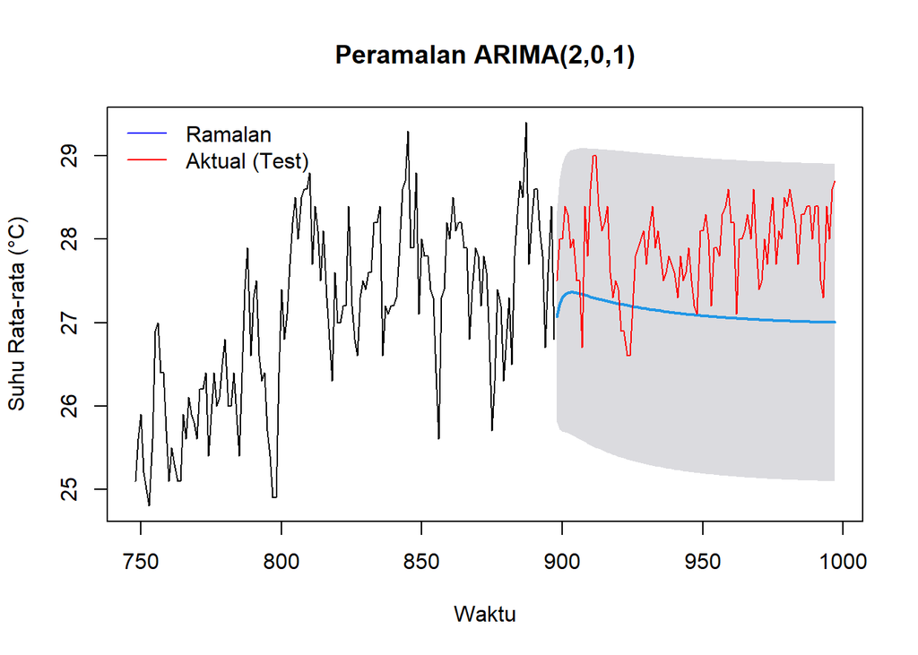

```r
plot(
  fc,
  include = min(150, length(y)),
  main = paste("Peramalan", best_name),
  ylab = "Suhu Rata-rata (°C)",
  xlab = "Waktu"
)

lines(
  (length(y) + 1):(length(y) + h),
  act,
  col = "red"
)

legend(
  "topleft",
  legend = c("Ramalan", "Aktual (Test)"),
  col = c("blue", "red"),
  lty = 1,
  bty = "n"
)
```

Sebagai pembanding sederhana, digunakan ramalan naif berupa nilai terakhir data *train*.

```r
naive_pred <- rep(tail(y, 1), h)

akurasi_naive <- c(
  MAE = mean(abs(act - naive_pred)),
  RMSE = sqrt(mean((act - naive_pred)^2)),
  MAPE = mean(abs((act - naive_pred) / act)) * 100
)

data.frame(
  Ukuran = names(akurasi),
  ARIMA = round(akurasi, 3),
  Naive = round(akurasi_naive, 3)
)
```

|  | Ukuran | ARIMA | Naive |
| --- | --- | --- | --- |
| MAE | MAE | 0.848 | 1.132 |
| RMSE | RMSE | 0.954 | 1.226 |
| MAPE | MAPE | 3.012 | 4.025 |

**Interpretasi:** Peramalan sebanyak 100 hari menghasilkan MAE sebesar 0.848, RMSE sebesar 0.954, dan MAPE sebesar 3.01%.

Sebagai pembanding, metode naif menghasilkan MAE sebesar 1.132, RMSE sebesar 1.226, dan MAPE sebesar 4.03%.

# Kesimpulan

Berdasarkan seluruh tahapan analisis, data suhu rata-rata harian Cilegon yang digunakan terdiri dari 997 amatan dan memenuhi syarat minimal 500 amatan. Data dibagi menjadi 897 amatan untuk data *train* dan 100 amatan untuk data *test*.

Pemeriksaan Box-Cox menghasilkan lambda optimum sebesar 0.51 dengan selang kepercayaan 95% sebesar [-0.97; 1.98]. Selang tersebut memuat angka 1 sehingga tidak dilakukan transformasi Box-Cox.

Uji ADF menghasilkan p-value 0.01. Data dianggap stasioner dalam rataan sehingga tidak diperlukan diferensiasi.

Berdasarkan ACF, PACF, dan EACF, beberapa model potensial kemudian diestimasi. Model yang dipilih adalah **ARIMA(2,0,1)** dengan AIC sebesar 1768.661.

Pada analisis sisaan, uji Ljung-Box menghasilkan p-value 0.4647, uji ARCH-LM menghasilkan p-value 0.0063, dan uji Shapiro-Wilk menghasilkan p-value 6.5494e-08.

Uji overfitting dilakukan dengan menambahkan satu orde AR dan satu orde MA. Hasilnya adalah sebagai berikut:

Terdapat model yang memiliki parameter tambahan signifikan atau AIC lebih kecil daripada model awal. Oleh karena itu hasil overfitting perlu dipertimbangkan kembali sebelum model akhir ditetapkan.

Pada data *test*, model menghasilkan MAE sebesar 0.848, RMSE sebesar 0.954, dan MAPE sebesar 3.01%.

Dengan demikian, seluruh tahapan pembuatan model ARIMA yang diminta dalam praktikum telah dilakukan, mulai dari pembagian data, pemeriksaan stasioneritas, penanganan ketidakstasioneran, identifikasi model, pendugaan dan pemilihan model, analisis sisaan, uji overfitting, hingga peramalan dan evaluasi pada data *test*.